# Rethinking microplastics: mapping the continuous and interrelated nature of shape, size and density of marine plastics in distributions

Lise Alkema, Caspar J. van Lissa, Merel Kooi, & A. A. Koelmans

12/24/2020

# 1 Methods

With regard to the dimensionality of particles, we can distinguish three cases:

Prior to analyses, we removed outliers separately for particles in these three categories. For lines, outliers were identified as cases with an absolute standardized value $> 3$. For films and fragments, outliers were identified as having a Mahalanobis distance $> 13.82$.

## 1.1 Strategy of analyses

To account for the differences in particle dimensionality, we used a stepwise plan of analysis:

1. Analyze the three dimensionality categories separately, using only the dimensions relevant for that particle.
2. Determine the best model and number of classes for each dimensionality category
3. Create a joint model, with number of classes and starting values based on step 2. Use starting values for the dichotomous indicator variables to ensure lines and films are assigned to the correct classes.

### 1.1.1 Lines

Lines effectively vary only across one dimension. Width and height are small and approximately constant (when compared to the variance in length). Thus, we conducted univariate mixture models, focusing on the dimension of length, estimating 1-5 classes with varying means and variances. As indicated in Table 1.1, BIC indicated that the 3-class model fitted best. However, the difference in BIC with the 2-class model was trivial, and the minimum classification probability of a 3-class solution was low, indicating poor separability for at least one class. Most importantly, visual inspection of the solution (Figure 1.1) suggested a bimodal distribution. We thus chose a 2-class solution.

Table 1.1: Line classification

| Model | Classes | LogLik | BIC | Entropy | $p_{min}$ | $p_{max}$ | $n_{min}$ | $n_{max}$ | $p_{BLRT}$ |
| --- | --- | --- | --- | --- | --- | --- | --- | --- | --- |
| 2 | 1 | -2057.716 | 4127.796 | 1.000 | 1.000 | 1.000 | 1.00000 | 1.00000 |  |
| 2 | 2 | -1925.192 | 3881.294 | 0.610 | 0.821 | 0.963 | 0.40289 | 0.59711 | 0.0000 |
| 2 | 3 | -1896.619 | 3842.695 | 0.639 | 0.715 | 0.949 | 0.13636 | 0.50000 | 0.0000 |
| 2 | 4 | -1893.219 | 3854.441 | 0.594 | 0.578 | 0.914 | 0.13017 | 0.39876 | 0.4286 |
| 2 | 5 | -1887.821 | 3862.191 | 0.651 | 0.610 | 0.892 | 0.03512 | 0.36570 | 0.2500 |

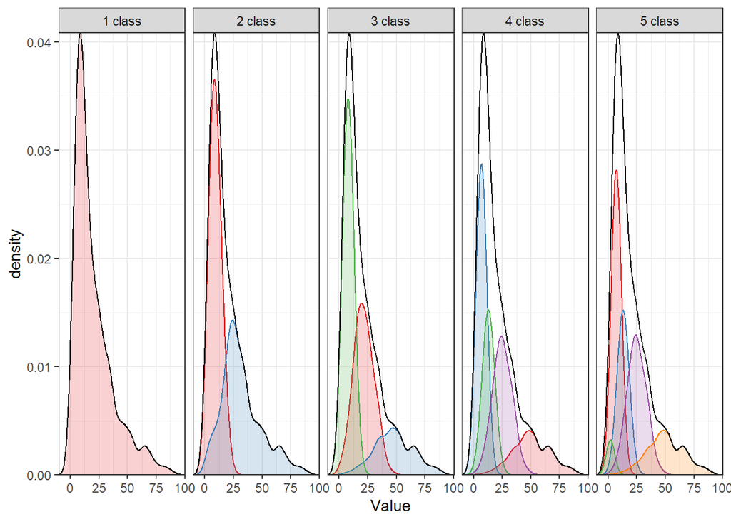

Figure 1.1: Mixture model of lines

### 1.1.2 Film

For film, we conducted bivariate mixture models of length and width, estimating 1-5 classes. We compared models with varying means and variances, to models that also included varying covariances. As indicated in Table 1.2, BIC values hardly differed between the models with fixed, and free covariances. We thus prefer the simpler models with fixed covariances. Furthermore, BIC showed a substantial drop from the 1- to 2-class solution, followed by a smaller drop to the 3-class solution, after which the decrease stabilized. Entropy was higher for the 2-class than for the 3-class solution, indicating that the two classes were more clearly separable. Visual inspection of the solutions (Figures 1.2 and 1.3) were inconclusive. Per Occam’s razor, we thus retained the simpler 2-class solution.

Table 1.2: Film classification

| Model | Classes | LogLik | BIC | Entropy | $p_{min}$ | $p_{max}$ | $n_{min}$ | $n_{max}$ | $p_{BLRT}$ |
| --- | --- | --- | --- | --- | --- | --- | --- | --- | --- |
| 4 | 1 | -3278.707 | 6591.158 | 1.000 | 1.000 | 1.000 | 1.00000 | 1.00000 |  |
| 4 | 2 | -2661.496 | 5390.480 | 0.906 | 0.900 | 0.992 | 0.16295 | 0.83705 | 0 |
| 4 | 3 | -2525.852 | 5152.935 | 0.806 | 0.833 | 0.960 | 0.13716 | 0.58148 | 0 |
| 4 | 4 | -2429.478 | 4993.931 | 0.817 | 0.826 | 0.948 | 0.03986 | 0.52403 | 0 |
| 4 | 5 | -2389.182 | 4947.083 | 0.836 | 0.874 | 0.939 | 0.03986 | 0.34232 | 0 |
| 6 | 1 | -3278.707 | 6591.158 | 1.000 | 1.000 | 1.000 | 1.00000 | 1.00000 |  |
| 6 | 2 | -2581.146 | 5236.528 | 0.794 | 0.855 | 0.980 | 0.23095 | 0.76905 | 0 |
| 6 | 3 | -2444.999 | 5004.727 | 0.725 | 0.820 | 0.944 | 0.14420 | 0.50528 | 0 |
| 6 | 4 | -2387.276 | 4929.773 | 0.732 | 0.797 | 0.923 | 0.12192 | 0.40445 | 0 |
| 6 | 5 | -2352.015 | 4899.744 | 0.755 | 0.796 | 0.924 | 0.04220 | 0.36225 | 0 |

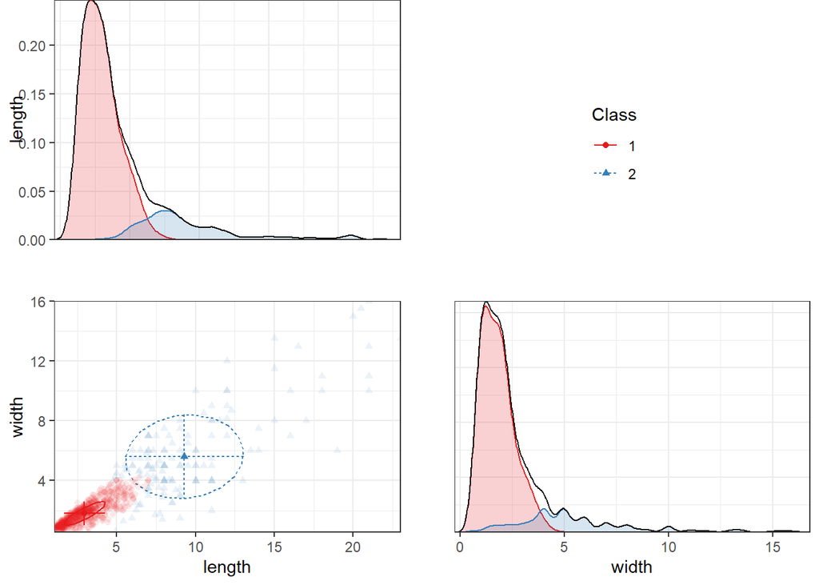

Figure 1.2: Mixture model of film with free means and variances, and fixed covariances

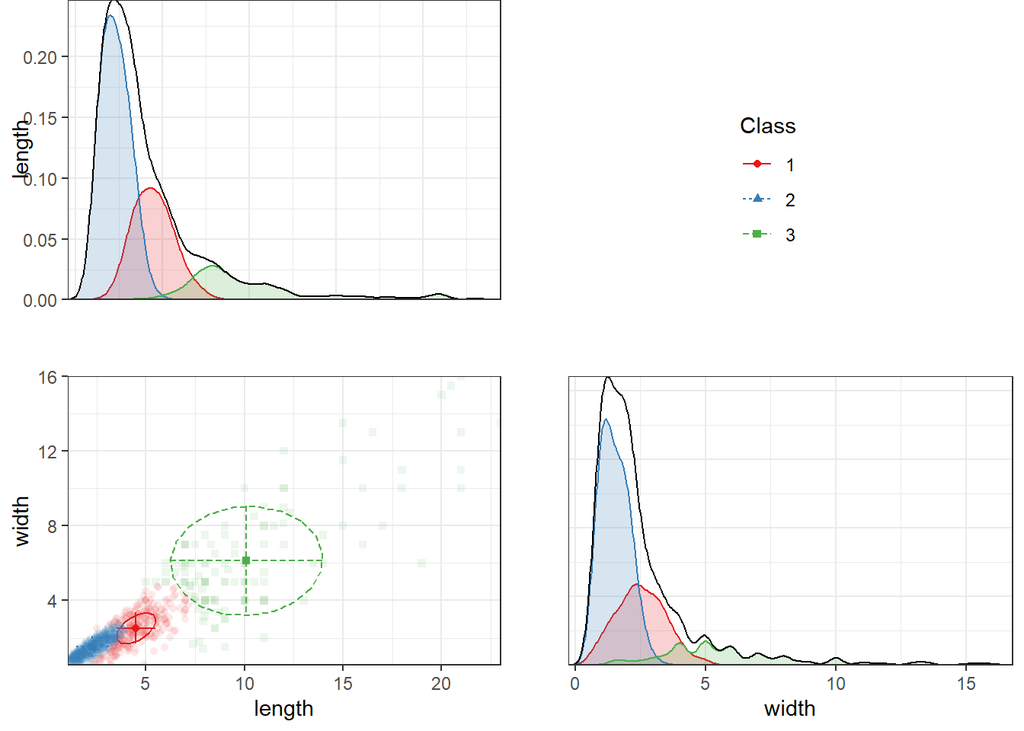

Figure 1.3: Mixture model of film with free means and variances, and fixed covariances

### 1.1.3 Fragment

Table 1.3: Fragment classification

| Model | Classes | LogLik | BIC | Entropy | $p_{min}$ | $p_{max}$ | $n_{min}$ | $n_{max}$ | $p_{BLRT}$ |
| --- | --- | --- | --- | --- | --- | --- | --- | --- | --- |
| 4 | 1 | -16554.68 | 33152.52 | 1.000 | 1.000 | 1.000 | 1.00000 | 1.00000 |  |
| 4 | 2 | -12490.03 | 25066.38 | 0.848 | 0.892 | 0.981 | 0.22605 | 0.77395 | 0 |
| 4 | 3 | -11503.06 | 23135.59 | 0.871 | 0.752 | 0.977 | 0.04728 | 0.69723 | 0 |
| 4 | 4 | -11012.19 | 22197.00 | 0.861 | 0.722 | 0.966 | 0.00714 | 0.60393 | 0 |
| 4 | 5 | -10765.52 | 21746.83 | 0.809 | 0.733 | 0.930 | 0.00535 | 0.44603 | 0 |
| 6 | 1 | -16554.68 | 33152.52 | 1.000 | 1.000 | 1.000 | 1.00000 | 1.00000 |  |
| 6 | 2 | -12433.71 | 24962.37 | 0.820 | 0.883 | 0.980 | 0.24996 | 0.75004 | 0 |
| 6 | 3 | -11098.19 | 22343.11 | 0.810 | 0.701 | 0.962 | 0.02480 | 0.59590 | 0 |
| 6 | 4 | -10703.53 | 21605.59 | 0.741 | 0.713 | 0.914 | 0.01463 | 0.36414 | 0 |
| 6 | 5 | -10472.26 | 21194.82 | 0.759 | 0.683 | 0.913 | 0.00196 | 0.35004 | 0 |

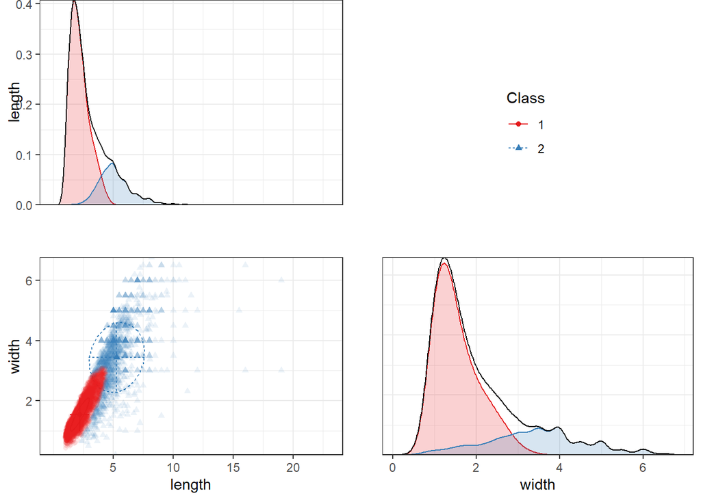

Figure 1.4: Mixture model of fragments with free means and variances, and fixed covariances

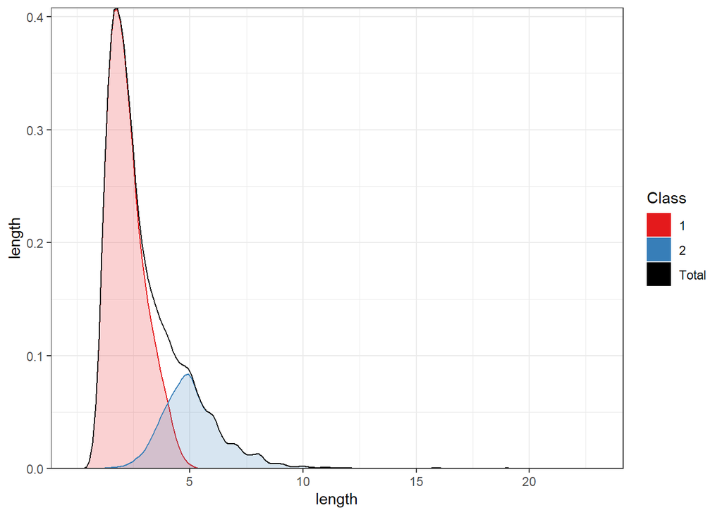

Figure 1.5: Mixture model of fragments with free means and variances, and fixed covariances

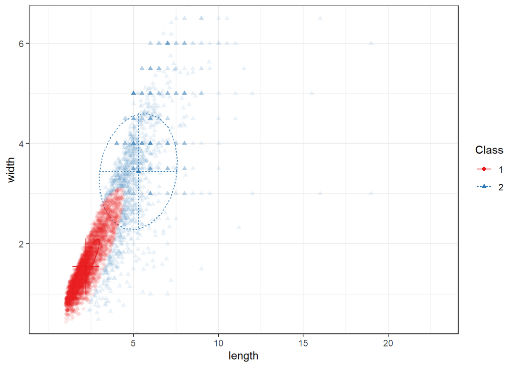

Figure 1.6: Mixture model of fragments with free means and variances, and fixed covariances

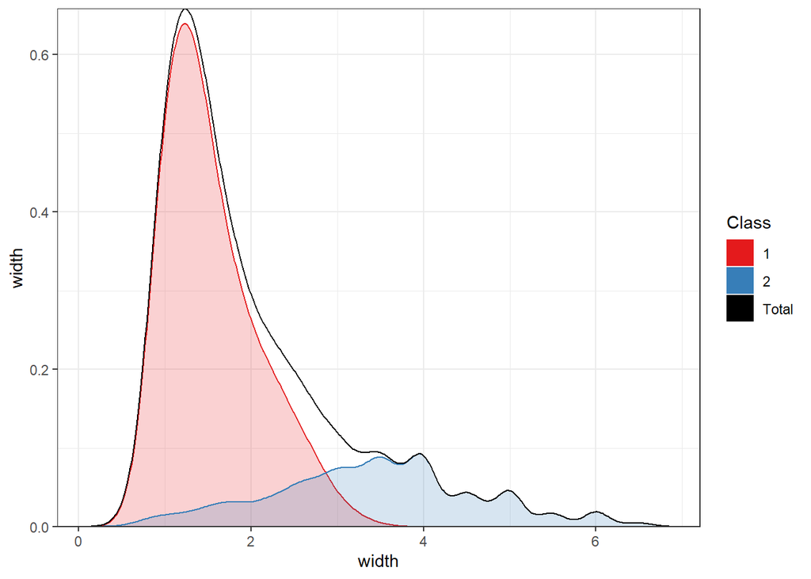

Figure 1.7: Mixture model of fragments with free means and variances, and fixed covariances

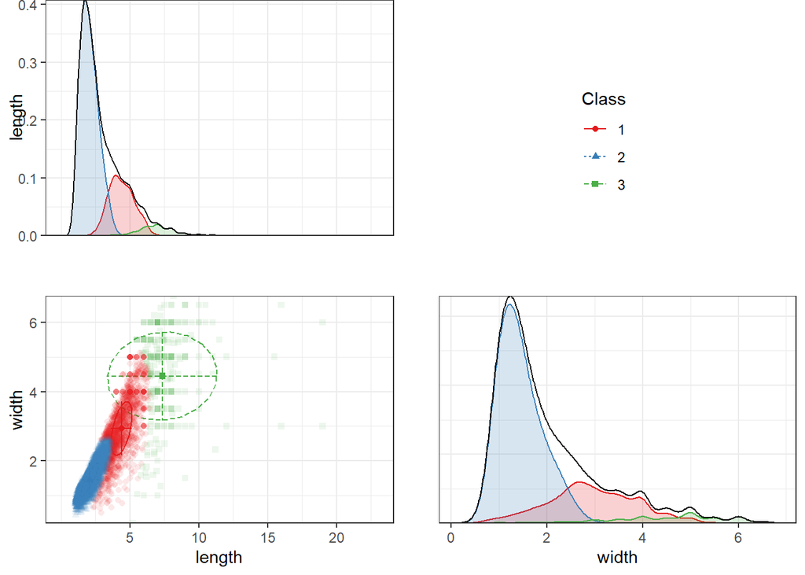

Figure 1.8: Mixture model of fragments with free means and variances, and fixed covariances

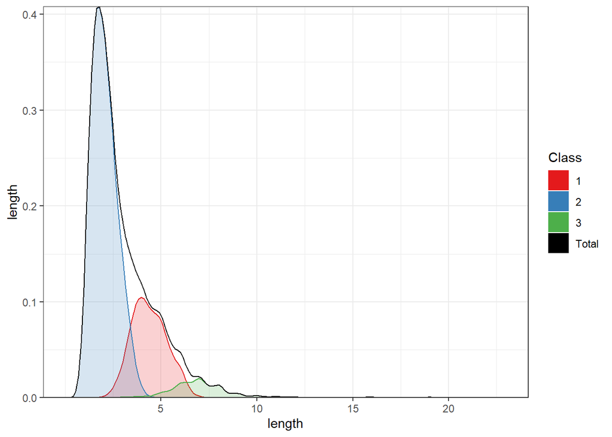

Figure 1.9: Mixture model of fragments with free means and variances, and fixed covariances

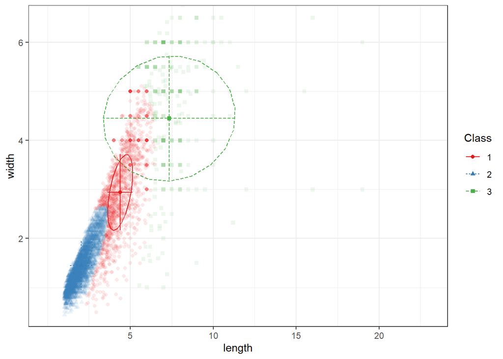

Figure 1.10: Mixture model of fragments with free means and variances, and fixed covariances

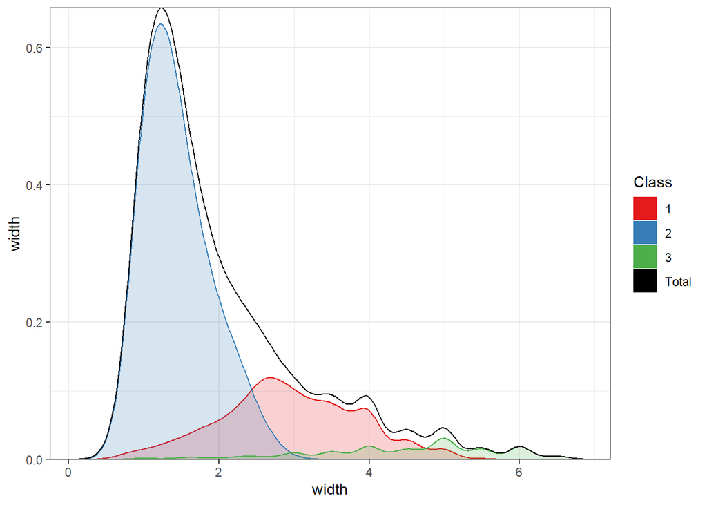

Figure 1.11: Mixture model of fragments with free means and variances, and fixed covariances

## 1.2 Combining the classes

To combine the models for lines, films, and fragments, we estimated a six-class mixture model. We used dummy variables to restrict potential class membership for the three categories to two classes each. Parameters involving width were not estimated for line classes. To account for non-independence of observations due to the clustered sampling (i.e., observations originating from the same haul of the net), we used a sandwich estimator for the standard errors.

The resulting model discriminated well between classes, Entropy $= 0.94$, posterior classification probabilities $[0.82, 0.99]$, AIC = 42760.41, BIC = 42945.24. The parameters of this classification are displayed in Tables 1.4.

Table 1.4: Combined model. Note: $M$: Mean, $s^2$: Variance, $r$: Correlation. * = p < .001

| Parameter | Value | 95% CI | Class |
| --- | --- | --- | --- |
| $M_{\text{length}}$ | 9.32* | [8.20, 10.44] | Line 1 (N = 289) |
| $s^2_{\text{length}}$ | 19.87* | [10.08, 29.65] | Line 1 (N = 289) |
| $M_{\text{length}}$ | 32.36* | [29.66, 35.06] | Line 2 (N = 195) |
| $s^2_{\text{length}}$ | 312.35* | [247.17, 377.52] | Line 2 (N = 195) |
| $r_{\text{length}, \text{width}}$ | 0.86* | [0.84, 0.88] | Film 1 (N = 714) |
| $M_{\text{length}}$ | 2.95* | [2.63, 3.26] | Film 1 (N = 714) |
| $M_{\text{width}}$ | 1.81* | [1.57, 2.05] | Film 1 (N = 714) |
| $s^2_{\text{length}}$ | 1.70* | [1.25, 2.15] | Film 1 (N = 714) |
| $s^2_{\text{width}}$ | 0.63* | [0.49, 0.76] | Film 1 (N = 714) |
| $r_{\text{length}, \text{width}}$ | 0.08* | [0.05, 0.12] | Film 2 (N = 139) |
| $M_{\text{length}}$ | 9.29* | [8.50, 10.09] | Film 2 (N = 139) |
| $M_{\text{width}}$ | 5.60* | [5.08, 6.12] | Film 2 (N = 139) |
| $s^2_{\text{length}}$ | 14.11* | [8.68, 19.55] | Film 2 (N = 139) |
| $s^2_{\text{width}}$ | 7.89* | [5.25, 10.54] | Film 2 (N = 139) |
| $r_{\text{length}, \text{width}}$ | 0.91* | [0.88, 0.94] | Fragment 1 (N = 4338) |
| $M_{\text{length}}$ | 2.21* | [1.93, 2.48] | Fragment 1 (N = 4338) |
| $M_{\text{width}}$ | 1.55* | [1.36, 1.73] | Fragment 1 (N = 4338) |
| $s^2_{\text{length}}$ | 0.63* | [0.32, 0.95] | Fragment 1 (N = 4338) |
| $s^2_{\text{width}}$ | 0.31* | [0.15, 0.46] | Fragment 1 (N = 4338) |
| $r_{\text{length}, \text{width}}$ | 0.15* | [0.07, 0.23] | Fragment 2 (N = 1267) |
| $M_{\text{length}}$ | 5.29* | [4.69, 5.89] | Fragment 2 (N = 1267) |
| $M_{\text{width}}$ | 3.44* | [3.15, 3.73] | Fragment 2 (N = 1267) |
| $s^2_{\text{length}}$ | 5.36 | [-2.56, 13.28] | Fragment 2 (N = 1267) |
| $s^2_{\text{width}}$ | 1.35* | [0.91, 1.80] | Fragment 2 (N = 1267) |

## 1.3 Observed height

Observed height was only assessed for particles with one dimension exceeding 5mm. Consequently, we did not involve it in the classification procedure, but we do explore relationships with observed height as a distal outcome. First, we examined the prevalence of observed height measurements across the six particle classes, based on most likely class membership. We found that only 5 particles with observed height were not classified as *large fragments*. Consequently, we analyzed observed height only for particles classified as *large fragments*. For these particles, we found that length was uncorrelated with height, $r < 0.01$, and width had a small correlation with height, $r = 0.24$. This again reinforces the notion that larger particles display greater heterogeneity in shapes.

## 1.4 Polymer type by class

To determine whether polymer type varied across class, while accounting for classification uncertainty, we used the three-step method by Bakk & Vermunt, 2014 (for the general method, see Asparouhov & Muthén, 2014). There were significant differences across classes for all three polymer types, with all $\chi^2 (5) > 95.42, ps < .001$. The resulting distribution of polymer types by class is displayed in Figure 1.12.

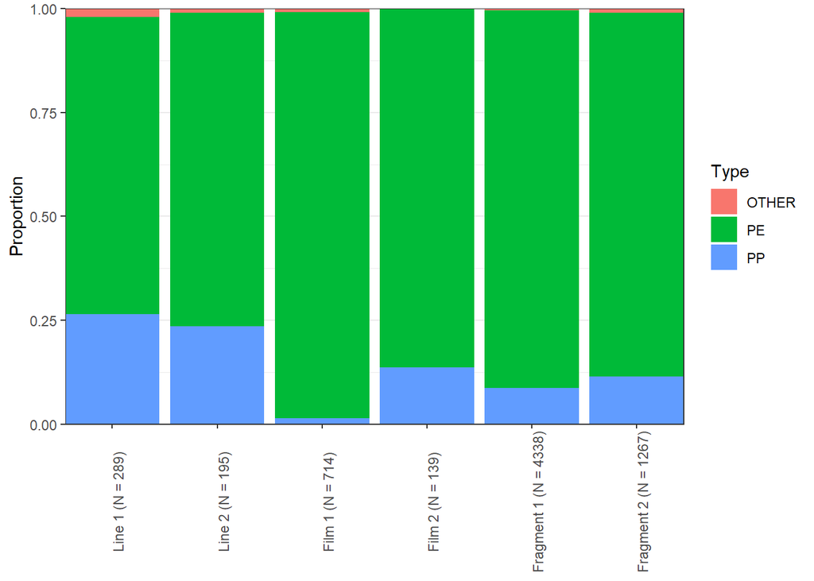

Figure 1.12: Proportion of polymer types by latent class.

# 2 Conclusions

These analyses suggest that the (uni- and multivariate) prevalence of ocean plastics is better described by a mixture of (multivariate) normal distributions than by a single (multivariate) normal distribution. Mathematical models of ocean plastic prevalence should take this deviation from (multivariate) normality into account.

We initially conducted separate analyses for lines, which vary primarily along the length dimension, films, which vary primarily along the length and width dimensions, and fragments. These fragments, like films, vary in length and width - but also in height. However, our methods of measurement precluded obtaining height data for smaller particles. Therefore, height data were very incomplete, so height was treated as an auxiliary variable. We finally combined analyses for all particles in a single model, and reported the results.

The results indicated that, for all types of particles, two classes could be distinguished: One class with smaller means and variances, and one class with larger means and variances. For films and fragments, we were additionally able to estimate covariances in these classes. Although the covariances were fixed to be equal across the two classes, they are standardized differently because the variances are freely estimated across the two classes. Thus, for films and fragments, we observe different standardized covariances (i.e., correlation coefficients) between length and width in the two classes. These correlation coefficients inform us about the (two-dimensional) shape of particles. High correlations reflect coextensive shapes (i.e., particles approximately as wide as they are long), whereas low correlations reflect variability in shapes.